# Filters slides

Filters

Synthese aan de hand van opamps

Jan Genoe

November 2025

###### Generic circuit

[figure not shown]

###### MNA matrix van het algemene circuit

- na invullen in de MNA matrix krijgen we:

###### MNA matrix van het algemene circuit

$$ \begin{bmatrix} \vdots & & & & & \vdots & & & \vdots \\ \dots & & & & & \dots & & & \dots \\ \vdots & & & & & \vdots & & & \vdots \\ \dots & & & & & \dots & \dots & & \dots \\ \vdots & & & & & \vdots & & & \vdots \end{bmatrix} \begin{bmatrix} \vdots \\ V_{out}(s) \\ \vdots\\ \\ \vdots \end{bmatrix} = \begin{bmatrix} \vdots \\ \\ \vdots \\ V_{in}(s)\\ \vdots \end{bmatrix} $$

###### Oplossing van de MNA matrix

- de transferfunctie wordt:

$$T(j \omega)=\frac{ V_{out}(j \omega)}{ V_{in}(j \omega)}=\frac{\sum\limits_{i=0}^{2n} a_i(j \omega)^i}{\sum\limits_{i=0}^{2n} b_i(j \omega)^i}$$

met $n$ het aantal knopen in het circuit. Het feit dat er in de som $2n$ voorkomt is omdat er in elk van de elementen van de matrix zowel een spoel als een condensator kan voorkomen. Veel circuits hebben echter geen spoelen (omdat deze moeilijk in te bouwen zijn op geïntegreerde schakelingen. In dat geval kunnen we de oplossing verder vereenvoudigen tot:

###### Oplossing van de MNA matrix zonder spoelen

- de transferfunctie wordt:

$$T(j \omega)=\frac{ V_{out}(j \omega)}{ V_{in}(j \omega)}=\frac{\sum\limits_{i=0}^{n} a_i(j \omega)^i}{\sum\limits_{i=0}^{n} b_i(j \omega)^i}$$

###### Oplossing van de MNA matrix zonder spoelen

- de transferfunctie wordt:

$$T(j \omega)=\frac{ V_{out}(j \omega)}{ V_{in}(j \omega)}=\frac{\sum\limits_{i=0}^{n} a_i(j \omega)^i}{\sum\limits_{i=0}^{n} b_i(j \omega)^i}= \frac{\prod\limits_{i=0}^{n} (j \omega- n_i)}{\prod\limits_{i=0}^{n} (j \omega-p_i)}$$

###### Realisatie in cascadeerbare actieve circuits

- Om een gevraagde transferfunctie te realiseren gaan we deze opsplitsen in een product van eentermen en tweetermen met reële coëfficiënten.
- We realiseren elk van deze circuits op zich en plaatsen ze gewoon achter elkaar.
  - Het volgende circuit mag wel het vorige niet belasten, anders verandert de transferfunctie.

$$T(j \omega)= \frac{\prod\limits_{i=0}^{n} (j \omega- n_i)}{\prod\limits_{i=0}^{n} (j \omega-p_i)}= T_1(j \omega) \times T_2(j \omega) \times T_3(j \omega) \times \dots \times T_n(j \omega) $$

###### Hardware implementatie in building blocks

[figure not shown]

###### Eerste en tweede orde filters

## Eerste en tweede orde filters

###### Transfer functie eerste orde bouwblok

De transfer functie van een eerste orde blok is:

###### Transfer functie eerste orde bouwblok

$$ V_{out}=-\frac{b_1(j \omega) +b_0}{a_1(j \omega) +a_0} V_{in}$$

###### Basisblok van een algemeen eerste orde filter

[figure not shown]

###### Basisblok in functie van de impedanties

[figure not shown]

###### Eerste orde laagdoorlaatfilter

[figure not shown]

###### Eerste orde hoogdoorlaatfilter

[figure not shown]

###### Eerste orde filter

[figure not shown]

###### Eerste orde filter

[figure not shown]

###### Transfer functie tweede orde blok

De transfer functie van een tweede orde blok is:

###### Transfer functie tweede orde blok

$$ V_{out} = - \frac{b_2 (j \omega)^2 + b_1(j \omega) +b_0}{a_2 (j \omega)^2 + a_1(j \omega) +a_0} V_{in}$$

###### Bovenste gedeelte van het BiQuad circuit

[figure not shown]

###### Het volledige BiQuad circuit

[figure not shown]

###### Sallen en Key laagdoorlaat circuit

[figure not shown]

###### Sallen and Key Low pass filter

```
* Sallen and Key Low pass filter
R1 1 2 10k
R2 2 3 10k
XOpAmp 3 4 8 9 5 8 opamp
C1 2 5 1.6nF
C2 3 0 1.6nF
Rkx 5 4 100k
Rx 4 0 100k
Vin 1 0 AC 0.5 0 DC 0
VPOS 8 0 DC +2.5V
VNEG 9 0 DC -2.5V
```

###### Sallen en Key LP: ideale 10 MHz opamp

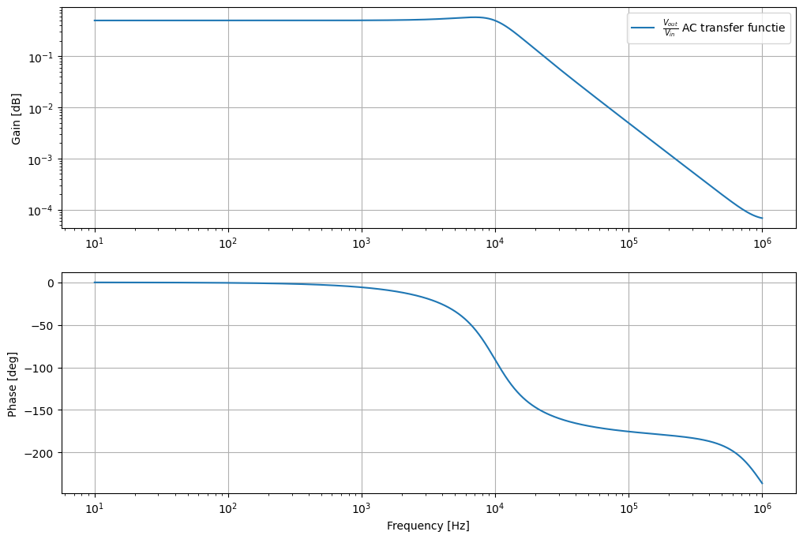

###### Sallen en Key LP: LMV981 opamp

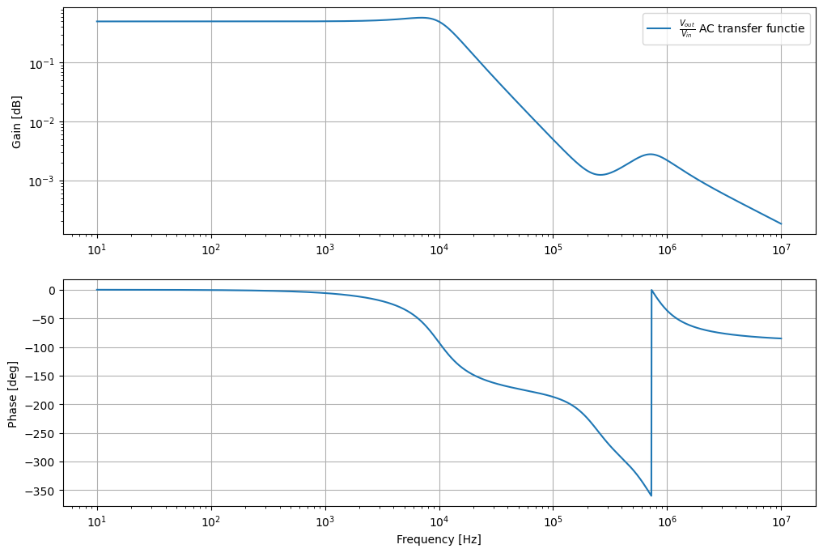

###### Sallen en Key hoogdoorlaat circuit

[figure not shown]

###### Sallen en Key banddoorlaat circuit

[figure not shown]

###### Sallen en Key banddoorlaat circuit (2)

[figure not shown]

###### Filter specificaties

## Filter specificaties

###### Filter specificaties: laagdoorlaatfilter

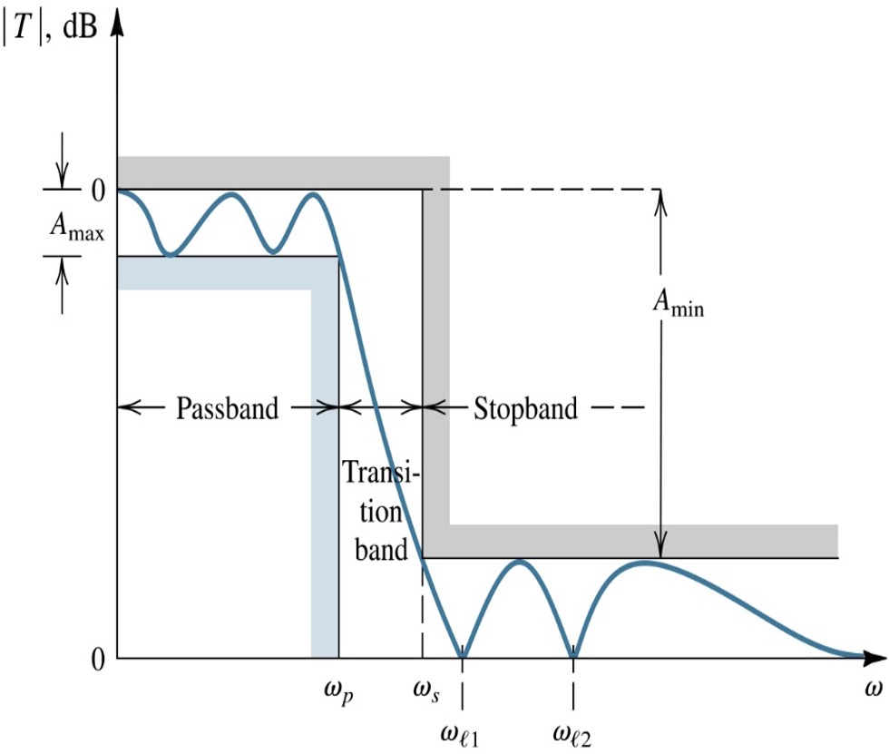

###### Filter specificaties: banddoorlaatfilter

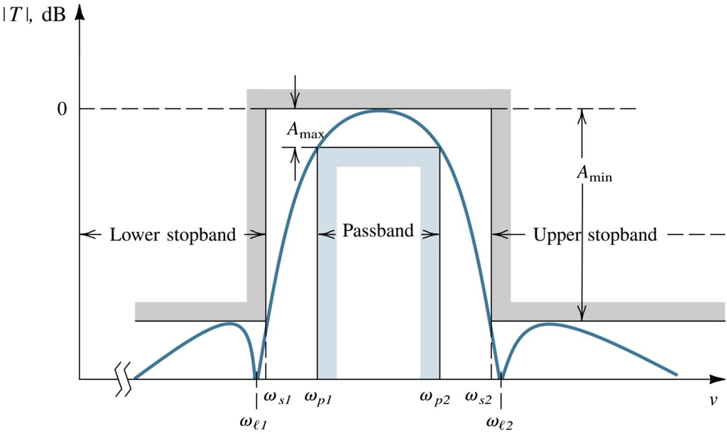

###### Filter types

De verschillende filters die we in dit hoofdstuk zullen ontwerpen zijn:

- Laagdoorlaat filter (**low-pass filter**)
- Hoogdoorlaat filter (**high-pass filter**)
- Alles doorlaat filter (**all-pass filter**)
- Banddoorlaat filter (**band-pass filter**)
- Bandsper filter (**band-stop filter**)

Op het eerste gezicht lijkt een allesdoorlaatfilter niet echt nuttig maar het belang hiervan zit hem in de invloed op de fase van het signaal.

###### Frequentietransformaties

## Frequentietransformaties

###### Frequentietransformaties

Hiervoor gaan we typisch de transferfunctie herschrijven als functie van de parameter S, die gelijk is aan:

$$S=\frac{i \omega}{\omega_o} $$

$$i \omega - p_i =\frac{i \omega}{\omega_o}- \frac{p_i}{\omega_o} = S - \frac{p_i}{\omega_o} $$

$$i \omega - n_i =\frac{i \omega}{\omega_o}- \frac{n_i}{\omega_o} = S - \frac{n_i}{\omega_o} $$

###### laagdoorlaatfilter naar hoogdoorlaatfilter

De frequentietransformatie die we hiervoor gebruiken is:

$$S=\frac{\omega_o}{i \omega} $$

###### laagdoorlaatfilter naar banddoorlaatfilter

De frequentietransformatie die we hiervoor gebruiken is:

$$S=\frac{1}{\omega_2-\omega_1}\frac{(i \omega)^2 + \omega_1\omega_2}{i \omega} $$

###### Specifieke filter blokken

## Specifieke filter blokken

###### Filter types

De verschillende filters die we in dit hoofdstuk zullen ontwerpen zijn:

- **Butterworth** filter
- **Chebyshev** filter
- **Invers Chebyshev** filter
- **Bessel-Thomson** filter

###### Butterworth 3de orde laagdoorlaatfilter: Transfer functie

Als eerste voorbeeld ontwerpen we een analoge 3de orde laagdoorlaatfilter van het type Butterworth met afsnijfrequentie 1 MHz. De transferfunctie $H(s)$ of $H(j\omega)$ die we bekomen is:

###### Butterworth 3de orde laagdoorlaatfilter: Transfer functie

$$ H(s) = \frac{\sum\limits_{n=0}^M b_n s^n}{\sum\limits_{n=0}^N a_n s^n} = \frac{\sum\limits_{n=0}^0 b_n s^n}{\sum\limits_{n=0}^3 a_n s^n}$$

###### Butterworth 3de orde laagdoorlaatfilter: Transfer functie

$a_n$ en $b_n$ zijn de coëfficiënten van de veeltermen in de transferfunctie. Aangezien we hier een derde orde laagdoorlaatfilter ontwerpen is $M=0$ en $N=3$. Voor deze oefening is het resultaat van de berekening van deze coëfficiënten:

###### Coeficienten derde orde Butterworth laagdoorlaatfilter (1 MHz)

```
Veelterm coefficienten teller: M= 0
b[ 0 ] = 2.4805021344239852e+20
Veelterm coefficienten noemer: N= 3
a[ 3 ] = 1.0
a[ 2 ] = 12566370.614359174
a[ 1 ] = 78956835208714.88
a[ 0 ] = 2.4805021344239852e+20
```

Een plot van deze transferfunctie zien we in {numref}`filter_Fig8`. We stellen inderdaad vast dat de versterking (Gain) heel erg vlak is tot 1 MHz en daarna met 60 dB per decade afneemt.

###### Amplitude en fase derde orde Butterworth laagdoorlaatfilter (1 MHz)

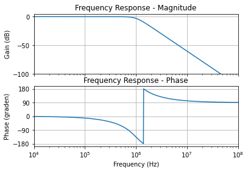

###### Polen derde orde Butterworth laagdoorlaatfilter(1 MHz)

```
Lijst der nullen: M= 0
Lijst der polen: N= 3
p[ 1 ] = (-3141592.6535897935+5441398.092702653j)
p[ 2 ] = (-6283185.307179586-0j)
p[ 3 ] = (-3141592.6535897935-5441398.092702653j)
```

###### Polen derde orde Butterworth laagdoorlaatfilter(1 MHz)

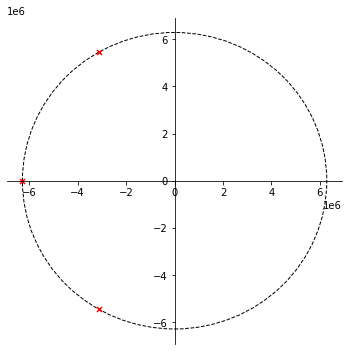

###### Opsplitsing derde orde Butterworth laagdoorlaatfilter

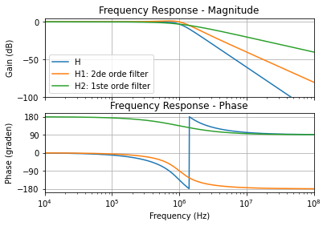

###### Detail rond de afsnijfrequentie

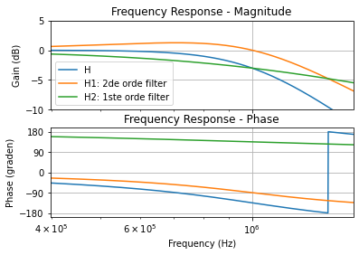

###### Opsplitsing in de bouwblokken H1 en H2

[figure not shown]

###### Implementatie tweede orde filter H1

[figure not shown]

###### Implementatie eerste orde filter H2

[figure not shown]

###### Coefficienten transferfunctie vijfde orde Butterworth laagdoorlaatfilter (1 MHz)

```
Veelterm coefficienten teller: M= 0
b[ 0 ] = 9.792629913129003e+33
Veelterm coefficienten noemer: N= 5
a[ 5 ] = 1.0
a[ 4 ] = 20332814.76926104
a[ 3 ] = 206711678220539.9
a[ 2 ] = 1.2988077794177306e+21
a[ 1 ] = 5.043559043399954e+27
a[ 0 ] = 9.792629913129004e+33
```

###### Amplitude en fase vijfde orde Butterworth laagdoorlaatfilter (1 MHz)

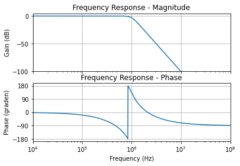

###### Polen vijfde orde Butterworth laagdoorlaatfilter (1 MHz)

```
Lijst der nullen: M= 0
Lijst der polen: N= 5
p[ 1 ] = (-1941611.0387254667+5975664.329483111j)
p[ 2 ] = (-5083203.69231526+3693163.6609809133j)
p[ 3 ] = (-6283185.307179586-0j)
p[ 4 ] = (-5083203.69231526-3693163.6609809133j)
p[ 5 ] = (-1941611.0387254667-5975664.329483111j)
```

###### Polen vijfde orde Butterworth laagdoorlaatfilter (1 MHz)

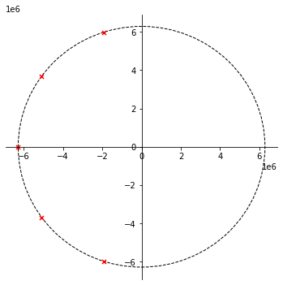

###### Opsplitsing in 3 transferfunkties

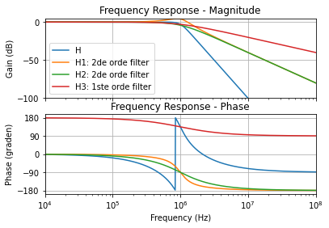

###### Hardware implementatie in 3 building blocks

[figure not shown]

###### Vergelijking derde en vijfde orde Butterworth laagdoorlaatfilter

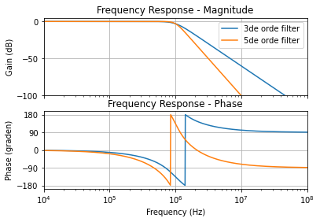

###### 7de orde Butterworth banddoorlaatfilter

```
Veelterm coefficienten teller: M= 7
b[ 7 ] = 6.334013983218556e+58
b[ 6 ] = 0.0
b[ 5 ] = 0.0
b[ 4 ] = 0.0
b[ 3 ] = 0.0
b[ 2 ] = 0.0
b[ 1 ] = 0.0
b[ 0 ] = 0.0
Veelterm coefficienten noemer: N= 14
a[ 14 ] = 1.0
a[ 13 ] = 1129455138.528784
a[ 12 ] = 7.760089165897884e+17
a[ 11 ] = 3.654151505077993e+26
a[ 10 ] = 1.293535546920629e+35
a[ 9 ] = 3.5017090931362664e+43
a[ 8 ] = 7.334620231296047e+51
a[ 7 ] = 1.1783749530590898e+60
a[ 6 ] = 1.4477960023023706e+68
a[ 5 ] = 1.3643931993116192e+76
a[ 4 ] = 9.948728770520122e+83
a[ 3 ] = 5.547604782936569e+91
a[ 2 ] = 2.325495035605259e+99
a[ 1 ] = 6.681091689314365e+106
a[ 0 ] = 1.1676379112645588e+114
```

###### 7de orde Butterworth banddoorlaatfilter

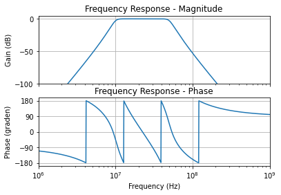

###### Polen van een 7de orde Butterworth banddoorlaatfilter

```
Lijst der nullen: M= 7
z[ 1 ] = 0j
z[ 2 ] = 0j
z[ 3 ] = 0j
z[ 4 ] = 0j
z[ 5 ] = 0j
z[ 6 ] = 0j
z[ 7 ] = 0j
Lijst der polen: N= 14
p[ 1 ] = (-9467553.01746494-62713329.10036281j)
p[ 2 ] = (-30211474.606362037-61659756.49600357j)
p[ 3 ] = (-58777850.02496373-58866599.60061156j)
p[ 4 ] = (-125663706.14359173-62831853.07179589j)
p[ 5 ] = (-58777850.02496373+58866599.60061156j)
p[ 6 ] = (-30211474.606362037+61659756.49600357j)
p[ 7 ] = (-9467553.01746494+62713329.10036281j)
p[ 8 ] = (-46458057.493502825+307739438.435567j)
p[ 9 ] = (-126488603.88224223+258155439.82934594j)
p[ 10 ] = (-167660324.09626448+167913476.98651484j)
p[ 11 ] = (-125663706.14359173+62831853.07179589j)
p[ 12 ] = (-167660324.09626448-167913476.98651484j)
p[ 13 ] = (-126488603.88224223-258155439.82934594j)
p[ 14 ] = (-46458057.493502825-307739438.435567j)
```

###### Polen van een 7de orde Butterworth banddoorlaatfilter

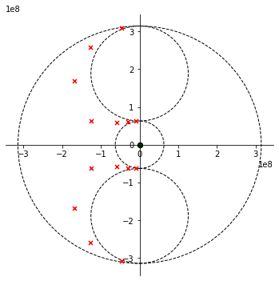

###### Vergelijking banddoorlaatfilter en opeenvolging laagdoorlaat- en hoogdoorlaatfilter

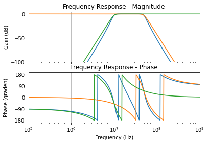

###### Transferfunctie 7de orde Butterworth banddoorlaatfilter

```
Veelterm coefficienten teller: M= 7
b[ 7 ] = 1.082225670413975e+53
b[ 6 ] = 0.0
b[ 5 ] = 0.0
b[ 4 ] = 0.0
b[ 3 ] = 0.0
b[ 2 ] = 0.0
b[ 1 ] = 0.0
b[ 0 ] = 0.0
Veelterm coefficienten noemer: N= 14
a[ 14 ] = 1.0
a[ 13 ] = 169418270.77931747
a[ 12 ] = 7.027364430041076e+17
a[ 11 ] = 1.0074611841037228e+26
a[ 10 ] = 2.1017496540749808e+35
a[ 9 ] = 2.488471395316168e+43
a[ 8 ] = 3.4683129207221617e+52
a[ 7 ] = 3.2679992552874596e+60
a[ 6 ] = 3.4107645311434367e+69
a[ 5 ] = 2.406576000783415e+77
a[ 4 ] = 1.998855398085796e+86
a[ 3 ] = 9.422413939327687e+93
a[ 2 ] = 6.463381596708082e+102
a[ 1 ] = 1.5323607880306775e+110
a[ 0 ] = 8.894760315452719e+118
```

###### Transferfunctie 7de orde Butterworth banddoorlaatfilter

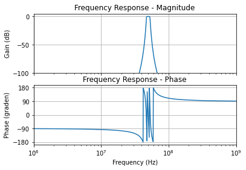

###### Polen van een 7de orde Butterworth banddoorlaatfilter

```
Lijst der nullen: M= 7
z[ 1 ] = 0j
z[ 2 ] = 0j
z[ 3 ] = 0j
z[ 4 ] = 0j
z[ 5 ] = 0j
z[ 6 ] = 0j
z[ 7 ] = 0j
Lijst der polen: N= 14
p[ 1 ] = (-3949021.641305336-295726397.242198j)
p[ 2 ] = (-11200424.836296545-298982612.7578789j)
p[ 3 ] = (-16539450.539423024-305061656.189032j)
p[ 4 ] = (-18849555.92153874-313026248.8897938j)
p[ 5 ] = (-16539450.539423024+305061656.189032j)
p[ 6 ] = (-11200424.836296545+298982612.7578789j)
p[ 7 ] = (-3949021.641305336+295726397.242198j)
p[ 8 ] = (-4439819.935339821+332480313.6424786j)
p[ 9 ] = (-12304586.93699407+328456965.2578802j)
p[ 10 ] = (-17426275.57876118+321418687.7969175j)
p[ 11 ] = (-18849555.92153874+313026248.8897938j)
p[ 12 ] = (-17426275.57876118-321418687.7969175j)
p[ 13 ] = (-12304586.93699407-328456965.2578802j)
p[ 14 ] = (-4439819.935339821-332480313.6424786j)
```

###### Polen van een 7de orde Butterworth banddoorlaatfilter

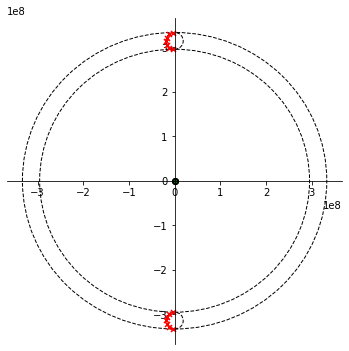

###### Vergelijking 7de orde banddoorlaatfilter en opeenvolging laagdoorlaat- en hoogdoorlaatfilter

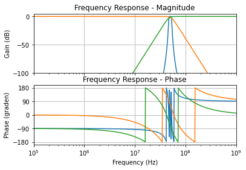

###### Chebyshev filter: Transferfunctie

De transferfunctie is:

- n rimpels in de doorlaatband

met:

met S voor een laagdoorlaatfilter:

De amplitude voor $\omega=\omega o$ is:

- dit is ook de amplitude van de rimpel

Boven deze frequentie daalt deze functie als:

$$ G^2_n(\omega)=\frac{1}{1+\epsilon^2 T_n^2(S)}$$

$$ T_n(x)=\cos(n \arccos(x) )$$

$$ S=\frac{j \omega}{\omega_o}$$

$$ |G_n(\omega=\omega_o)|=\frac{1}{\sqrt{1+\epsilon^2}}$$

$$ |G_n(S)| \approx \frac{1}{\epsilon^2 2^{n-1} | S|^n }$$

###### Chebyshev filter: verschil even en oneven orde

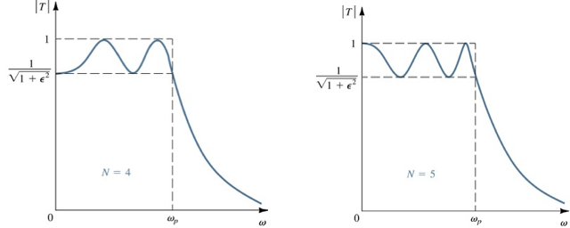

$$ G^2_n(\omega)=\frac{1}{1+\epsilon^2 T_n^2(S)}$$

###### Chebyshev filter: plaats van de polen

Deze laagdoorlaatfilter heeft enkel polen Deze polen liggen op een ellips in het complexe vlak We plaatsen de polen eerst zoals Butterworth op een circel Op basis van de rimpel bepalen we de parameter a:

De reële as vermenigvuldigen we met: De complexe as vermenigvuldigen we met:

De polen met hetzelfde reëel deel vormen een 2de graads veelterm:

$$ a= \frac{1}{n} \sinh^{-1} \frac{1}{\epsilon} $$

$$ \omega_o \sinh(a) $$

$$ \omega_o \cosh(a) $$

$$ s^2+ 2 \Re(p_k) s +\omega_x^2 $$

###### Invers Chebyshev filter: Transferfunctie

De transferfunctie is:

- n rimpels in de sperband

met:

met S voor een laagdoorlaatfilter:

De polen zijn de omgekeerden (1/p) is van de Chebyshev filter

- deze liggen niet op een cirkel

$$ G^2_n(\omega)=\frac{\epsilon^2 T_n^2(j/S)}{1+\epsilon^2 T_n^2(j/S)}$$

$$ T_n(x)=\cos(n \arccos(x) )$$

$$ S=\frac{j \omega}{\omega_o}$$

###### Bessel-thomson filter (Delay filter)

We willen de output een vaste vertraging geven ten opzichte van de ingang.

Hiervoor moet de fase lineair veranderen met de ingang.

We drukken de group delay uit als een reeksontwikkeling van w, en stellen hierin zoveel mogelijk coëfficiënten gelijk aan nul

###### 40 MHz Chebyshev laagdoorlaatfilter

```
Veelterm coefficienten teller: M= 0
b[ 0 ] = 2.298652790795694e+24
Veelterm coefficienten noemer: N= 3
a[ 3 ] = 1.0
a[ 2 ] = 92822184.81844565
a[ 1 ] = 5.168208012246375e+16
a[ 0 ] = 2.2986527907956946e+24
```

###### 40 MHz Chebyshev laagdoorlaatfilter

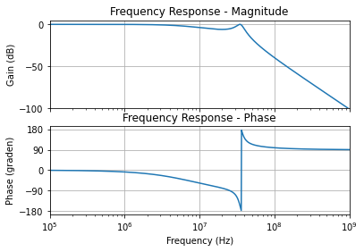

###### Detail van de 6dB passband

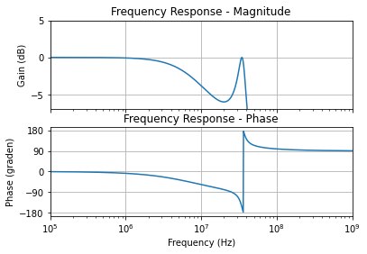

###### Polen derde orde 40 MHz Chebyshev laagdoorlaatfilter

```
Lijst der nullen: M= 0
Lijst der polen: N= 3
p[ 1 ] = (-23205546.204611413+221335928.5095666j)
p[ 2 ] = (-46411092.40922282-0j)
p[ 3 ] = (-23205546.204611413-221335928.5095666j)
```

###### Polen derde orde 40 MHz Chebyshev laagdoorlaatfilter

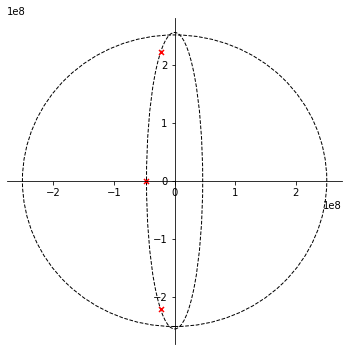

###### 120 MHz 8ste orde Chebyshev laagdoorlaatfilter

```
Veelterm coefficienten teller: M= 0
b[ 0 ] = 1.0669416336250132e+69
Veelterm coefficienten noemer: N= 8
a[ 8 ] = 1.0
a[ 7 ] = 524820305.9616953
a[ 6 ] = 1.2746966037803576e+18
a[ 5 ] = 5.1937707944741785e+26
a[ 4 ] = 5.104888759746549e+35
a[ 3 ] = 1.45769782715832e+44
a[ 2 ] = 6.590270478283454e+52
a[ 1 ] = 1.0103634193419598e+61
a[ 0 ] = 1.3431999354717115e+69
```

###### 120 MHz 8ste orde Chebyshev laagdoorlaatfilter

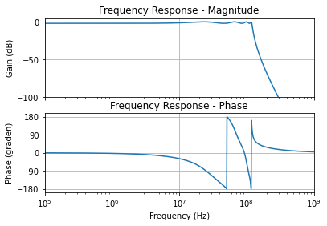

###### Detail van de 2dB passband

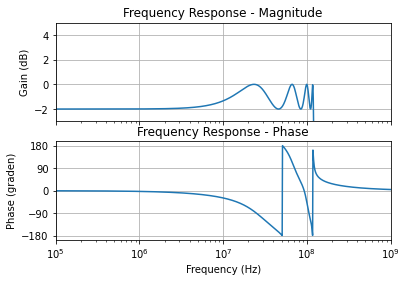

###### Polen 120 MHz Chebyshev laagdoorlaatfilter

```
Lijst der nullen: M= 0
Lijst der polen: N= 8
p[ 1 ] = (-19974783.518686887+746281824.2305412j)
p[ 2 ] = (-56883370.83720408+632667181.5530242j)
p[ 3 ] = (-85131980.59479763+422734695.6263414j)
p[ 4 ] = (-100420018.03015907+148444684.39010677j)
p[ 5 ] = (-100420018.03015907-148444684.39010677j)
p[ 6 ] = (-85131980.59479763-422734695.6263414j)
p[ 7 ] = (-56883370.83720408-632667181.5530242j)
p[ 8 ] = (-19974783.518686887-746281824.2305412j)
```

###### Polen 120 MHz Chebyshev laagdoorlaatfilter

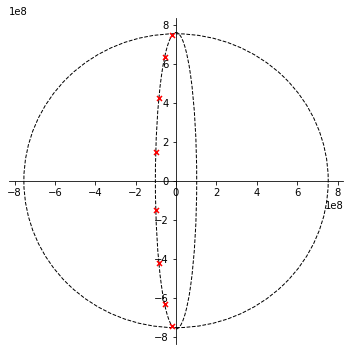

###### Vergelijking Butterworth en Chebyshev laagdoorlaatfilters (8ste orde)

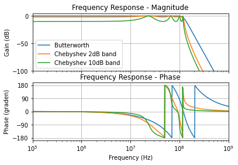

###### Transferfunctie Chebyshev 30 MHz laagdoorlaatfilter

```
Veelterm coefficienten teller: M= 0
b[ 0 ] = 1.780752121671573e+16
Veelterm coefficienten noemer: N= 2
a[ 2 ] = 1.0
a[ 1 ] = 121560720.41014235
a[ 0 ] = 2.5153792295277244e+16
```

###### Transferfunctie Chebyshev 30 MHz laagdoorlaatfilter

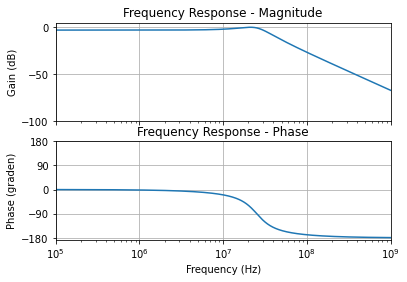

###### Polen van de Chebyshev 30 MHz laagdoorlaatfilter

```
Lijst der nullen: M= 0
Lijst der polen: N= 2
p[ 1 ] = (-60780360.20507117+146490750.93199244j)
p[ 2 ] = (-60780360.20507117-146490750.93199244j)
```

###### Polen van de Chebyshev 30 MHz laagdoorlaatfilter

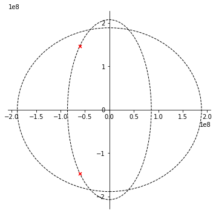

###### Transferfunktie van een Bessel Thomson hoogdoorlaatfilter (1 kHz)

```
Veelterm coefficienten teller: M= 2
b[ 2 ] = 1.0
b[ 1 ] = 0.0
b[ 0 ] = 0.0
Veelterm coefficienten noemer: N= 2
a[ 2 ] = 1.0
a[ 1 ] = 10882.796185405305
a[ 0 ] = 39478417.60435742
```

###### Transferfunktie van een Bessel Thomson hoogdoorlaatfilter (1 kHz)

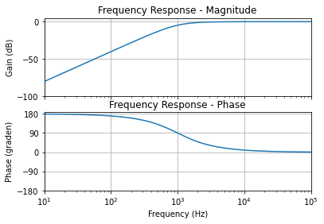

###### Switched Capacitor filters

## Switched Capacitor filters

Voor de integratie van filters op geïntegreerde schakelingen worden vaak geschakelde condensatoren (Switched Capacitors) gebruikt omwille van de volgende reden:

###### Switched Capacitor weerstand (SC)

- Weerstanden op chip zijn nooit heel erg nauwkeurig
- We kunnen een weerstand vervangen door een condensator en 2 schakelaars

$$i=f C_s (V_{in}-V_{out})$$

$$R=\frac{1}{f C_s }$$

###### Betere SC weerstand

- Het eenvoudige circuit heeft last van de parasitaire capaciteiten
- Het verdubbelen van de schakelaars lost dit probleem op

$$i=f C_s (V_{in}-V_{out})$$

$$R=\frac{1}{f C_s }$$

###### Verbeterde Switched Capacitor weerstand

[figure not shown]

###### Bovenste gedeelte van het BiQuad circuit

[figure not shown]

###### SC BiQuad filter

[figure not shown]

I would rather have questions that can't be answered  
than answers that can't be questioned.

Richard Feynman